# Lecture 26: Interpreting Confidence

Associated Textbook Sections: [13.3, 13.4](https://ccsf-math-108.github.io/textbook/chapters/13/3/Confidence_Intervals.html)

## Outline

- Bootstrap Confidence Intervals
- Visualizing Confidence
- Use Methods Appropriately
- Confidence Intervals For Testing

## Set Up the Notebook

```python
from datascience import *
import numpy as np
%matplotlib inline
import matplotlib.pyplot as plt
plt.style.use('fivethirtyeight')
```

## Bootstrap Confidence Intervals

### Bootstrap the Distribution of a Statistic

Simulation method to estimate the sample distribution of your statistic.

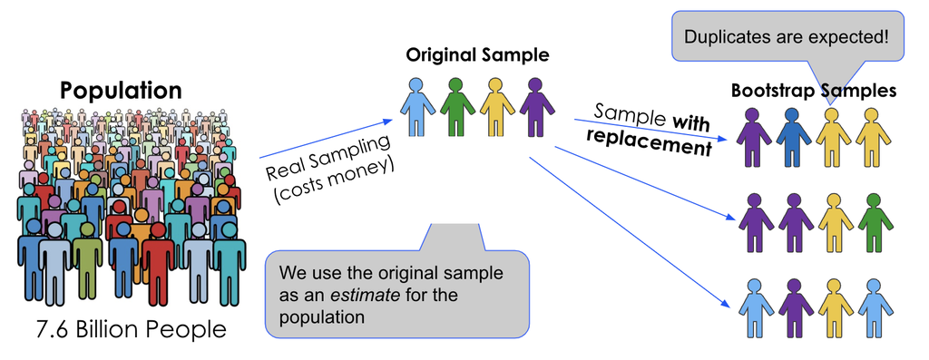

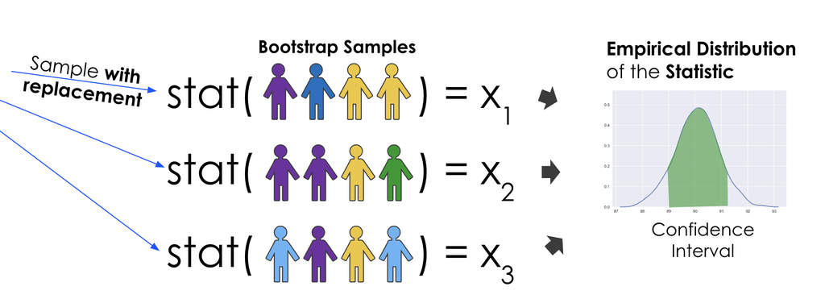

### A Bootstrap Confidence Interval

Construct a 95% confidence interval by taking the 2.5% and (100 - 2.5)% percentiles:

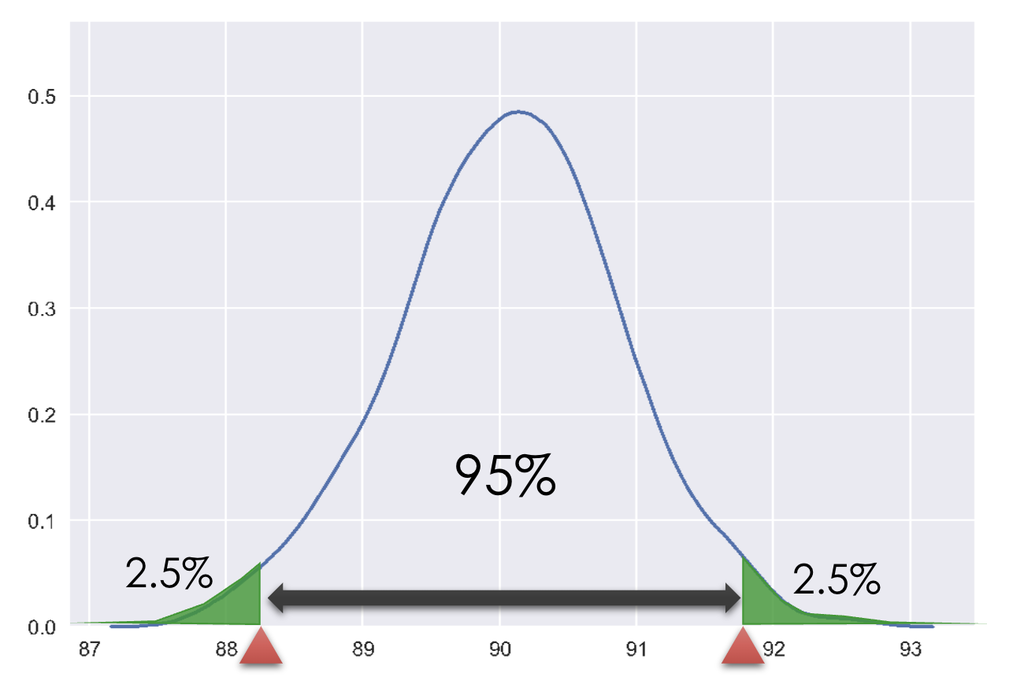

### The Bootstrap in Words

- From the original sample,
  - draw at random
  - **with replacement**
    - Otherwise you would always get the same sample
  - **Use the same sample size** as the original sample
    - The size of the new sample has to be the same as the original one, so that estimates are comparable
- For each sample, **compute the statistic**
- Compute **empirical distribution of the statistics**

## Visualizing Confidence

### 95% Confidence Interval

- Interval of estimates of a parameter
- Based on random sampling
- 95% is called the confidence level
  - Could be any percent between 0 and 100
  - Higher level means wider intervals
- A "good" interval is one that contains the parameter
- The confidence is in the process that creates the interval:
  - It generates a "good" interval about 95% of the time.

### The Meaning of 95% Confidence

> The confidence is in the process that gives the interval: It generates a "good" interval about 95% of the time.

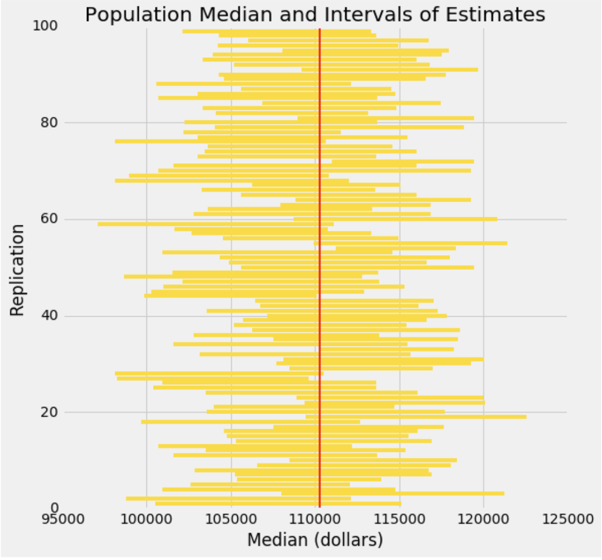

- Each yellow line in the visual represents a confidence interval from a fresh sample from the population.
- The red line marks the parameter being estimated by the intervals.
- Approximately 95% of the yellow lines intersect the red line.

### Visualizing Confidence

A similar/interactive tool to help visualize the meaning of a confidence interval: [Interpreting Confidence Intervals](https://rpsychologist.com/d3/ci/)

- *The Greek letter $\mu$ is used to symbolize the parameter.*
- In our class, the sampling distribution comes from the statistics we calculate using bootstrap resamples.

```python
%%html
<iframe src="https://rpsychologist.com/d3/ci#settings" width="800" height="600"></iframe>
```

[interactive chart not shown]

## Use Methods Appropriately

### When Not to Use Our Bootstrap Method

- If you're trying to estimate any parameter that's greatly affected by rare elements of the population very high or very low percentiles, or min and max
- If the probability distribution of your statistic is not roughly bell-shaped (the shape of the empirical distribution will be a clue)
- If the original sample is very small

### Demo: Create a Confidence Interval for Unknown Population Mean

- Load the `baby.csv` data from the Kaiser-supported study on the relationship between smoking during pregnancy and low-weight births.
- Visualize the distribution of maternal ages.
- Compute the mean age of mothers in the sample.

```python
births = Table.read_table('baby.csv')
births
```

| Birth Weight | Gestational Days | Maternal Age | Maternal Height | Maternal Pregnancy Weight | Maternal Smoker |
| --- | --- | --- | --- | --- | --- |
| 120 | 284 | 27 | 62 | 100 | False |
| 113 | 282 | 33 | 64 | 135 | False |
| 128 | 279 | 28 | 64 | 115 | True |
| 108 | 282 | 23 | 67 | 125 | True |
| 136 | 286 | 25 | 62 | 93 | False |
| 138 | 244 | 33 | 62 | 178 | False |
| 132 | 245 | 23 | 65 | 140 | False |
| 120 | 289 | 25 | 62 | 125 | False |
| 143 | 299 | 30 | 66 | 136 | True |
| 140 | 351 | 27 | 68 | 120 | False |

... (1164 rows omitted)

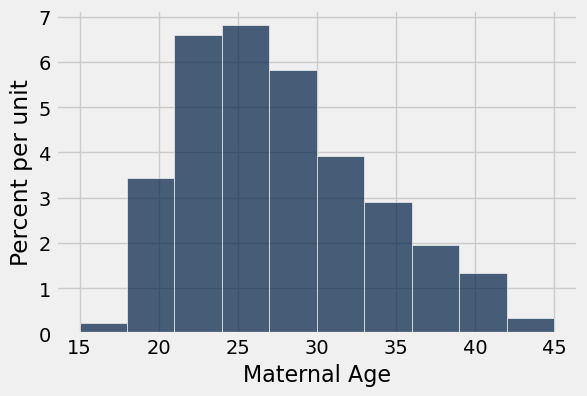

```python
births.hist('Maternal Age')
```

```python
np.mean(births.column('Maternal Age'))
```

```
27.228279386712096
```

**Question**: What is the mean age of the mothers in the population?

```python
def one_bootstrap_mean():
    resample = births.sample()
    return np.mean(resample.column('Maternal Age'))
```

```python
num_repetitions = 3_000
bstrap_means = make_array()
for i in np.arange(num_repetitions):
    bstrap_means = np.append(bstrap_means, one_bootstrap_mean())
```

```python
left = percentile(2.5, bstrap_means)
right = percentile(97.5, bstrap_means)

make_array(left, right)
```

```
array([ 26.89437819,  27.55877342])
```

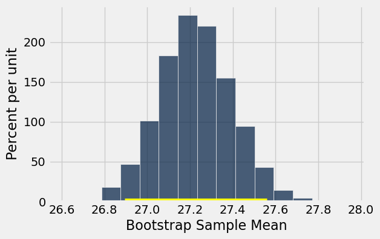

```
We are 95% confident that the mean age of the mothers in the population is between 26.894378194207835 and 27.5587734241908 years old.
```

```python
resampled_means = Table().with_columns(
    'Bootstrap Sample Mean', bstrap_means
)
resampled_means.hist(bins=15)
plt.plot([left, right], [0, 0], color='yellow', lw=8)
plt.show()
print(f"We are 95% confident that the mean age of the mothers in the population is between {left} and {right} years old.")
```

### An Incorrect Use

#### Confidence Interval

By our calculation, an approximate 95% confidence interval for the average age of the mothers in the population is (26.9, 27.6) years.

#### Incorrect Statement

About 95% of the mothers in the population were between 26.9 years and 27.6 years old.

#### Reasoning

We're estimating that their average age is in this interval.

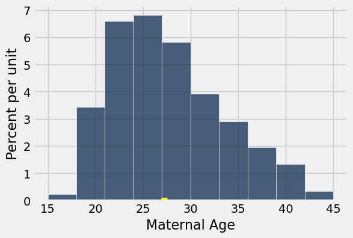

```python
births.hist('Maternal Age')
plt.plot([left, right], [0, 0], color='yellow', lw=8);
```

### An Incorrect Interpretation

#### Confidence Interval

An approximate 95% confidence interval for the average age of the mothers in the population is (26.9, 27.6) years.

#### Incorrect Statement

There is a 0.95 probability that the average age of mothers in the population is in the range 26.9 to 27.6 years.

#### Reasoning

The parameter is fixed, and the interval (26.9, 27.6) is fixed. The parameter is either in that interval or not. Once you've picked an interval, there's no probability involved.

### A Correct Interpretation

#### Confidence Interval

An approximate 95% confidence interval for the average age of the mothers in the population is (26.9, 27.6) years.

#### Correct Statement

If we generated confidence intervals in the same way many times, then approximately 95% of the intervals would contain the true average age of mothers in the population.

### Another Correct Interpretation

#### Confidence Interval

An approximate 95% confidence interval for the average age of the mothers in the population is (26.9, 27.6) years.

#### Correct Statement

There is a 95% chance the 95% confidence interval calculated from a given **future** sample will contain the average age of the mothers in the population.

### 95% Confidence

- Interval of estimates of a parameter
- Based on random sampling
- The process results in a random interval
- A "good" interval is one that contains the parameter
- The confidence is in the process that creates the interval: It generates a "good" interval (approximately) 95% of the time.

## Confidence Intervals For Testing

### Using a CI for Testing

- Null hypothesis: $\text{Population mean} = x$
- Alternative hypothesis: $\text{Population mean} \neq x$
- Cutoff for p-value: p%
- Method:
  - Construct a (100-p)% confidence interval for the population mean
  - Make a decision:
    - If x is not in the interval, reject the null
    - If x is in the interval, can't reject the null

### Using the Confidence Interval for Testing Hypotheses

- **Null Hypothesis:** The mean age of mothers in the population is 25 years; the random sample average is different due to chance.
- **Alternative Hypothesis:** The mean age of the mothers in the population is not 25 years.
- **Cutoff**: Suppose you use the 5% cutoff for the p-value.

Since 25 is not in the constructed 95% confidence interval estimate for the mean age (26.9, 27.6), then reject the null hypothesis.

## Attribution

This content is licensed under the Creative Commons Attribution-NonCommercial-ShareAlike 4.0 International License (CC BY-NC-SA 4.0) and derived from the Data 8: The Foundations of Data Science offered by the University of California, Berkeley.